# 🌾 Drought Severity Forecasting Using SPI (LSTM Regression)

## 📝 Overview

This notebook implements a time-series regression approach to forecast drought severity using the Standardized Precipitation Index (SPI), derived from rainfall data across multiple weather stations.

We use a Long Short-Term Memory (LSTM) neural network to predict future SPI values based on past trends. These forecasts can later be mapped to drought categories using standard SPI thresholds.

## 🔧 Functionality

- Imports and preprocesses rainfall data from multiple CSV files
- Computes SPI values (3-month scale)
- Generates lag features for temporal modeling
- Trains and evaluates LSTM models for SPI regression
- Visualizes prediction performance over time

## 📦 Dependencies

- `pandas`, `numpy`, `scikit-learn`, `matplotlib`, `tensorflow`

```python
# Importing Required Libraries

# Data manipulation and math
import pandas as pd
import numpy as np
import scipy.stats as st

# Visualization
import matplotlib.pyplot as plt
import seaborn as sns
sns.set(style='whitegrid')

# Machine learning tools
from sklearn.ensemble import RandomForestClassifier
from sklearn.model_selection import train_test_split
from sklearn.metrics import classification_report, confusion_matrix
from sklearn.preprocessing import MinMaxScaler

# Deep learning (LSTM)
import tensorflow as tf
from tensorflow.keras.models import Sequential
from tensorflow.keras.layers import LSTM, Dense
from tensorflow.keras.optimizers import Adam

# Miscellaneous
import os
```

## 📥 Load and Clean Data

This section loads monthly rainfall data from multiple CSV files, cleans the column names, handles missing values, and formats the dates. Each station's data is tagged with a station name and resampled to ensure consistent monthly frequency.

```python
# Load and clean rainfall data from multiple weather station CSV files

file_paths = [
    './data/Gauge 1 _ Livingstone.csv',
    './data/UmeRiver.csv',
    './data/Gauge 2_ Kalomo.csv',
    './data/Gauge 3_Gwayi River.csv',
]

def clean_station_data(file_path):
    df = pd.read_csv(file_path)

    # Clean column names
    df.columns = df.columns.str.strip().str.replace('\t', '', regex=False)
    df = df.rename(columns={df.columns[0]: 'Date', df.columns[1]: 'Rainfall'})

    # Parse dates and remove invalid rows
    df['Date'] = pd.to_datetime(df['Date'], errors='coerce')
    df = df[['Date', 'Rainfall']].dropna()

    # Resample to monthly and add station label
    df = df.set_index('Date').resample('M').sum()
    df['Station'] = os.path.splitext(os.path.basename(file_path))[0]

    return df

# Load and concatenate data from all stations
stations = [clean_station_data(f) for f in file_paths]
data = pd.concat(stations).reset_index()

data.head()
```

|  | Date | Rainfall | Station |
| --- | --- | --- | --- |
| 0 | 2000-01-31 | 28.0298 | Gauge 1 _ Livingstone |
| 1 | 2000-02-29 | 13.0888 | Gauge 1 _ Livingstone |
| 2 | 2000-03-31 | 17.6432 | Gauge 1 _ Livingstone |
| 3 | 2000-04-30 | 16.7934 | Gauge 1 _ Livingstone |
| 4 | 2000-05-31 | 11.0411 | Gauge 1 _ Livingstone |

## Calculate Standardized Precipitation Index (SPI)

The Standardized Precipitation Index (SPI) quantifies meteorological drought by comparing observed precipitation with long-term historical norms. It is a widely accepted drought metric that transforms precipitation values into a normalized score.

### **SPI Calculation Logic**

1. **Rolling Summation**  
   Aggregate precipitation over a defined window (e.g., 3 months for SPI-3).
2. **Fit a Gamma Distribution**  
   Precipitation data typically follows a gamma distribution due to its skewed, positive nature.
3. **Compute CDF (Cumulative Probability)**  
   Convert rolling totals into cumulative probabilities using the fitted gamma distribution.
4. **Handle Zero Precipitation**  
   Since many regions have months with zero rainfall, this step adjusts the SPI calculation:
   - Calculate the proportion `q` of zero values.
   - Apply a mixed distribution:
     - For zero values: SPI uses `q`
     - For positive values: SPI uses `q + (1 - q) * gamma_cdf(x)`
5. **Standard Normal Transformation**  
   Convert CDF values into SPI values using the inverse of the standard normal distribution.

### **SPI Interpretation**

| SPI Range | Drought Class |
| --- | --- |
| > -0.5 | No Drought |
| -0.99 to -0.5 | Mild Drought |
| -1.49 to -1.0 | Moderate Drought |
| -1.99 to -1.5 | Severe Drought |
| < -2.0 | Extreme Drought |

This approach is essential in regions with dry seasons, where rainfall often includes many zero observations. The use of a gamma-zero mixed distribution is standard practice in SPI computation.

```python
# Function to calculate SPI using a mixed gamma-normal distribution
def calculate_spi_gamma(series, scale=3):
    """
    Calculates SPI values using a gamma distribution fit on rolling sums.

    Parameters:
        series (pd.Series): Monthly rainfall amounts.
        scale (int): Number of months for rolling aggregation (e.g., 3 for SPI-3).

    Returns:
        pd.Series: SPI values indexed by date.
    """
    rolled = series.rolling(window=scale).sum().dropna()

    # Probability of zero rainfall
    q = len(rolled[rolled == 0]) / len(rolled)

    # Fit gamma only on positive values
    rolled_positive = rolled[rolled > 0]
    if len(rolled_positive) < 2:
        return pd.Series(np.nan, index=rolled.index)

    shape, loc, scale_param = st.gamma.fit(rolled_positive, floc=0)

    # Calculate cumulative probability with zero-adjustment
    cdf_values = np.zeros(len(rolled))
    for i, value in enumerate(rolled.values):
        if value == 0:
            cdf_values[i] = q
        else:
            cdf_values[i] = q + (1 - q) * st.gamma.cdf(value, shape, loc=loc, scale=scale_param)

    # Convert to standard normal (SPI)
    spi_values = st.norm.ppf(cdf_values)

    return pd.Series(spi_values, index=rolled.index)

# Function to classify SPI into drought levels
def classify_drought(spi):
    if spi > -0.5:
        return 'No Drought'
    elif -0.99 < spi <= -0.5:
        return 'Mild Drought'
    elif -1.49 < spi <= -1.0:
        return 'Moderate Drought'
    elif -1.99 < spi <= -1.5:
        return 'Severe Drought'
    else:
        return 'Extreme Drought'

# Process data for each station
processed_stations = []
for station, group in data.groupby('Station'):
    group = group.copy()
    group['SPI3'] = calculate_spi_gamma(group['Rainfall'], scale=3)
    group.dropna(inplace=True)

    # Classify drought categories
    group['Drought_Class'] = group['SPI3'].apply(classify_drought)
    group['Drought_Label'] = group['Drought_Class'].astype('category').cat.codes

    # Add lag features for SPI
    for i in range(1, 4):
        group[f'SPI3_t-{i}'] = group['SPI3'].shift(i)

    group.dropna(inplace=True)
    processed_stations.append(group)

# Final dataset with features and targets
final_df = pd.concat(processed_stations)
final_df.head()
```

|  | Date | Rainfall | Station | SPI3 | Drought_Class | Drought_Label | SPI3_t-1 | SPI3_t-2 | SPI3_t-3 |
| --- | --- | --- | --- | --- | --- | --- | --- | --- | --- |
| 5 | 2000-06-30 | 8.9863 | Gauge 1 _ Livingstone | -0.651577 | Mild Drought | 1 | -0.361402 | -0.298470 | 0.017380 |
| 6 | 2000-07-31 | 4.0495 | Gauge 1 _ Livingstone | -1.183505 | Moderate Drought | 2 | -0.651577 | -0.361402 | -0.298470 |
| 7 | 2000-08-31 | 22.0938 | Gauge 1 _ Livingstone | -0.713716 | Mild Drought | 1 | -1.183505 | -0.651577 | -0.361402 |
| 8 | 2000-09-30 | 34.1830 | Gauge 1 _ Livingstone | 0.058007 | No Drought | 3 | -0.713716 | -1.183505 | -0.651577 |
| 9 | 2000-10-31 | 16.4665 | Gauge 1 _ Livingstone | 0.357827 | No Drought | 3 | 0.058007 | -0.713716 | -1.183505 |

## 🔍 Exploratory Data Analysis (EDA)

### 📊 Drought Class Distribution

This visualization provides insight into the frequency of each drought severity category, based on the SPI-derived drought classification.

### 🔎 Key Insights

- **Frequency Analysis**  
  A `countplot` is used to display how often each `Drought_Class` appears in the dataset.
- **Class Imbalance Detection**  
  Identifying whether some classes (e.g., "No Drought") dominate helps guide preprocessing steps for model training.
- **Understanding Trends**  
  Frequent occurrence of specific drought categories may reflect long-term climatic patterns or regional conditions.

### ✅ Why This Matters

1. **Supports Model Decisions**  
   Imbalanced classes can bias model performance. Visualization alerts us to possible mitigation strategies like class weighting or oversampling.
2. **Historical and Spatial Analysis**  
   Frequency of extreme or moderate drought may vary by station or time, helping policymakers and analysts plan mitigation strategies.
3. **Data Quality and Consistency**  
   Sudden spikes or rare categories can signal anomalies or genuine rare events.

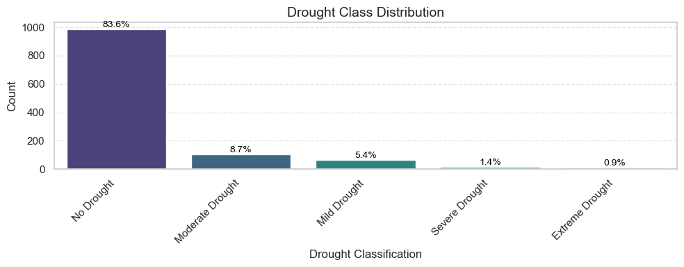

```python
# EDA: Drought Class Distribution with Percentage Labels
plt.figure(figsize=(10, 4))
ax = sns.countplot(
    data=final_df,
    x='Drought_Class',
    order=final_df['Drought_Class'].value_counts().index,
    palette='viridis'  # Optional: improves visual appeal
)

# Annotate each bar with percentage
total = len(final_df)
for p in ax.patches:
    percentage = f'{100 * p.get_height() / total:.1f}%'
    ax.annotate(
        percentage,
        (p.get_x() + p.get_width() / 2, p.get_height()),
        ha='center', va='bottom',
        fontsize=10, color='black'
    )

plt.title('Drought Class Distribution', fontsize=14)
plt.xlabel('Drought Classification', fontsize=12)
plt.ylabel('Count', fontsize=12)
plt.xticks(rotation=45, ha='right')
plt.grid(axis='y', linestyle='--', alpha=0.5)
plt.tight_layout()
plt.show()
```

### 📊 SPI Mean per Year Summary

Statistical Summaries: Mean SPI per Year To quantify drought severity, calculating the average SPI value per year will help determine long-term precipitation trends.

```python
# Extract year from the Date column
final_df['Year'] = final_df['Date'].dt.year
```

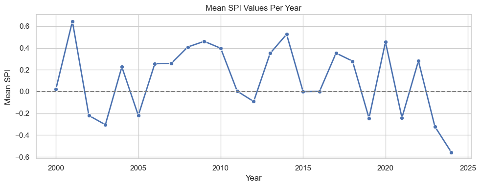

```python
if 'Year' in final_df.columns:
    spi_summary = final_df.groupby('Year')['SPI3'].mean().reset_index()

    plt.figure(figsize=(10, 4))
    sns.lineplot(data=spi_summary, x='Year', y='SPI3', marker='o', linewidth=2)
    plt.axhline(0, linestyle='--', color='gray')  # Baseline for normal precipitation
    plt.title('Mean SPI Values Per Year')
    plt.xlabel('Year')
    plt.ylabel('Mean SPI')
    plt.grid(True)
    plt.tight_layout()
    plt.show()
```

### 🌡 Heatmap of SPI Trends Over Time

Heatmap: SPI Trends Over Time A heatmap can provide a clearer visual representation of how SPI values fluctuate over months and years.

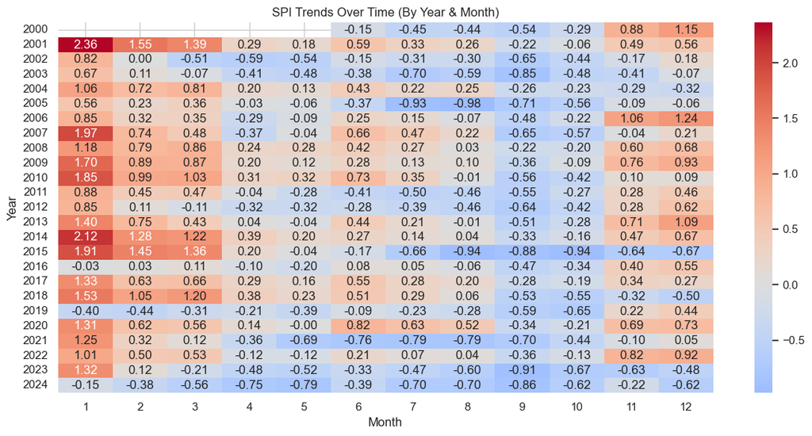

```python
if 'Year' in final_df.columns and 'Date' in final_df.columns:
    # Extract year and month
    final_df['Month'] = final_df['Date'].dt.month
    spi_pivot = final_df.pivot_table(values='SPI3', index='Year', columns='Month', aggfunc='mean')

    plt.figure(figsize=(12, 6))
    sns.heatmap(spi_pivot, cmap='coolwarm', annot=True, fmt=".2f", center=0)
    plt.title('SPI Trends Over Time (By Year & Month)')
    plt.xlabel('Month')
    plt.ylabel('Year')
    plt.tight_layout()
    plt.show()
```

## 🧠 LSTM Model: Train/Test Split and Forecasting

## **Preparing Data for LSTM-Based SPI Forecasting**

After cleaning and exploring the dataset, we now move to **time-series forecasting** using Long Short-Term Memory (LSTM) networks. This section covers:

### **Key Steps**

1. **Normalize SPI Values**
   - Scaling SPI values ensures stable model training.
   - Uses `MinMaxScaler` to map SPI values between **0 and 1**.
2. **Feature Engineering: Lagged SPI Values**
   - Creates lagged SPI values (`SPI3_t-1`, `SPI3_t-2`, `SPI3_t-3`) as input features.
   - Helps the model learn past patterns to predict future drought conditions.
3. **Formatting Data for LSTM**
   - Converts structured data into **sequences** suitable for deep learning models.
   - LSTM processes **3-month sequences** to predict future SPI values.

### **Why This Step is Important**

✔ **Captures temporal dependencies**—SPI trends over multiple months.  
✔ **Prepares the dataset for deep learning**—ensuring optimal format for LSTM processing.  
✔ **Establishes a baseline for multi-step forecasting**—training the model to predict SPI values in advance.

Next, we implement the **LSTM model architecture** and begin training to forecast drought severity.

[output not shown]

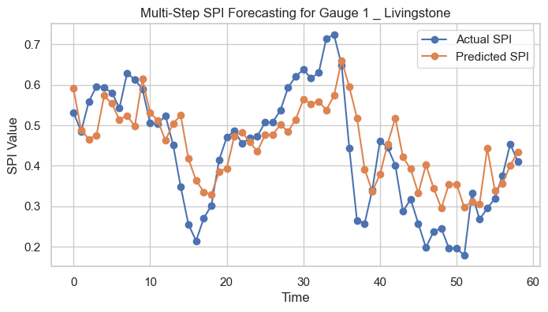

[output not shown]

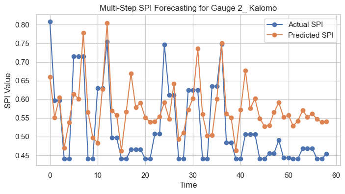

[output not shown]

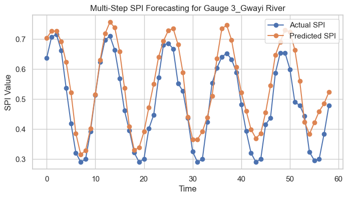

[output not shown]

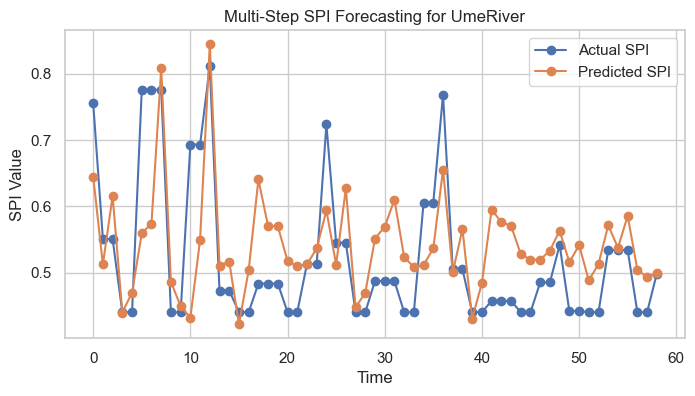

```python
# Normalize SPI values for better convergence
scaler = MinMaxScaler()
final_df[['SPI3', 'SPI3_t-1', 'SPI3_t-2', 'SPI3_t-3']] = scaler.fit_transform(final_df[['SPI3', 'SPI3_t-1', 'SPI3_t-2', 'SPI3_t-3']])

# Prepare LSTM-compatible input format
def create_sequences(data, target, sequence_length=3):
    X, y = [], []
    for i in range(len(data) - sequence_length):
        X.append(data[i:i + sequence_length].values)
        y.append(target.iloc[i + sequence_length])
    return np.array(X), np.array(y)

models = {}
sequence_length = 3

for station, group in final_df.groupby('Station'):
    X = group[['SPI3_t-1', 'SPI3_t-2', 'SPI3_t-3']]
    y = group['SPI3']

    # Create sequences
    X_seq, y_seq = create_sequences(X, y, sequence_length)

    # Train/test split
    train_size = int(len(X_seq) * 0.8)
    X_train, X_test = X_seq[:train_size], X_seq[train_size:]
    y_train, y_test = y_seq[:train_size], y_seq[train_size:]

    # Build LSTM model
    model = Sequential([
        LSTM(50, activation='relu', return_sequences=False, input_shape=(sequence_length, X_train.shape[-1])),
        Dense(1)  # Output future SPI value
    ])

    model.compile(optimizer=Adam(learning_rate=0.01), loss='mse')

    # Train LSTM model
    model.fit(X_train, y_train, epochs=50, batch_size=16, verbose=1)

    # Predict next SPI values
    y_pred = model.predict(X_test)

    models[station] = (model, X_test, y_test, y_pred)

    # Plot actual vs predicted SPI values
    plt.figure(figsize=(8, 4))
    plt.plot(y_test, label='Actual SPI', marker='o')
    plt.plot(y_pred, label='Predicted SPI', marker='o')
    plt.legend()
    plt.title(f'Multi-Step SPI Forecasting for {station}')
    plt.xlabel('Time')
    plt.ylabel('SPI Value')
    plt.grid(True)
    plt.show()
```

### 📈 Saving models

```python
# Save the trained model for each station
for station, (model, X_test, y_test, y_pred) in models.items():
    model.save(f'./models/lstm_spi_{station}.h5')  # Save as .h5 format
    print(f"Model for {station} saved successfully!")
```

[output not shown]

```
Model for Gauge 1 _ Livingstone saved successfully!
Model for Gauge 2_ Kalomo saved successfully!
Model for Gauge 3_Gwayi River saved successfully!
Model for UmeRiver saved successfully!
```

```python
# Save predictions for each station
for station, (model, X_test, y_test, y_pred) in models.items():
    results_df = pd.DataFrame({
        'Actual_SPI': y_test,
        'Predicted_SPI': y_pred.flatten()
    })

    results_df.to_csv(f'predictions_{station}.csv', index=False)
    print(f"Predictions saved for {station}")
```

```
Predictions saved for Gauge 1 _ Livingstone
Predictions saved for Gauge 2_ Kalomo
Predictions saved for Gauge 3_Gwayi River
Predictions saved for UmeRiver
```

## **Model Evaluation: Goodness-of-Fit Tests**

After making SPI predictions, we now assess **how well the LSTM model fits the data** using key metrics:

### **Metrics Used**

1. **Mean Squared Error (MSE)**
   - Measures average squared differences between actual and predicted SPI values.
   - Lower MSE indicates better forecasting accuracy.
2. **Root Mean Squared Error (RMSE)**
   - Provides a more interpretable measure of model error magnitude.
   - Helps compare models for performance.
3. **R² Score (Coefficient of Determination)**
   - Evaluates how well the predictions explain SPI trends.
   - Values closer to **1** indicate a strong fit.
4. **Residual Analysis**
   - Visualizes prediction errors.
   - Helps detect biases in SPI forecasts.

### **Why This Step is Important**

✔ Identifies model accuracy before applying predictions.  
✔ Helps improve the forecasting framework for better drought predictions.  
✔ Supports refinement of hyperparameters and data preprocessing.

Next, we run the goodness-of-fit tests for each trained model.

```
===== Model Evaluation for Gauge 1 _ Livingstone =====
Mean Squared Error (MSE): 0.0094
Root Mean Squared Error (RMSE): 0.0969
R² Score: 0.5707
```

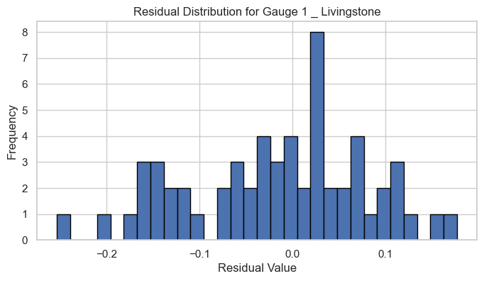

```
===== Model Evaluation for Gauge 2_ Kalomo =====
Mean Squared Error (MSE): 0.0090
Root Mean Squared Error (RMSE): 0.0948
R² Score: 0.1732
```

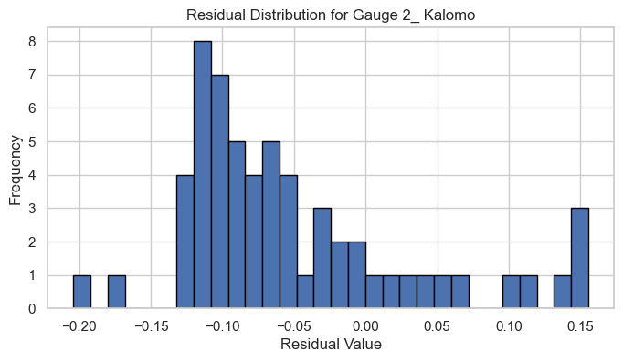

```
===== Model Evaluation for Gauge 3_Gwayi River =====
Mean Squared Error (MSE): 0.0053
Root Mean Squared Error (RMSE): 0.0725
R² Score: 0.7362
```

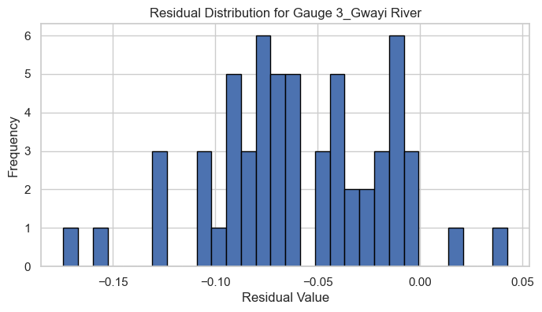

```
===== Model Evaluation for UmeRiver =====
Mean Squared Error (MSE): 0.0076
Root Mean Squared Error (RMSE): 0.0874
R² Score: 0.3412
```

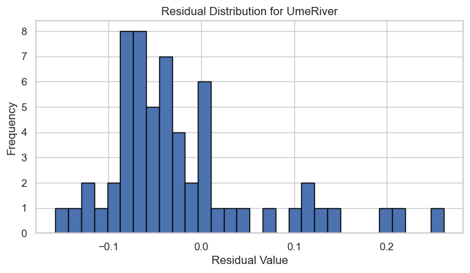

```python
from sklearn.metrics import mean_squared_error, r2_score
import numpy as np

# Evaluate each model
for station, (model, X_test, y_test, y_pred) in models.items():
    mse = mean_squared_error(y_test, y_pred)
    rmse = np.sqrt(mse)
    r2 = r2_score(y_test, y_pred)

    print(f"\n===== Model Evaluation for {station} =====")
    print(f"Mean Squared Error (MSE): {mse:.4f}")
    print(f"Root Mean Squared Error (RMSE): {rmse:.4f}")
    print(f"R² Score: {r2:.4f}")

    # Residual analysis (errors)
    residuals = y_test - y_pred.flatten()

    plt.figure(figsize=(8, 4))
    plt.hist(residuals, bins=30, edgecolor='black')
    plt.title(f"Residual Distribution for {station}")
    plt.xlabel("Residual Value")
    plt.ylabel("Frequency")
    plt.grid(True)
    plt.show()
```